◀ Back to Course Hub PAF 512 | Advanced Regression

# Interrupted Time Series | Codethrough

PAF 512 - Advanced Regression

# What will we cover?

#### 1. Run a naive Interrupted Time Series Model

- Preview, Wrangle, and Model our Data
- Run ITS and Interpret Coefficients

#### 2. Check for Autocorrelation

- Durbin-Watson Test
- Visualize ACF

#### 3. Adjust for Autocorrelation

- Re-estimate Standard Errors (Newey-West)
- Introduce a Control Variable (Seasonality)
- Re-run ITS with Control Variable

#### 4. Counterfactual Analysis

- Predict Actual vs. Counterfactual Outcomes

#### 5. Introduce a Control Group

- Generate Synthetic Control Data
- Run a Controlled ITS Model
- Interpret Controlled ITS Coefficients

# Data

We will use the **UKDriverDeaths** dataset, which contains the monthly total of road deaths or serious injuries in Great Britain from January 1969 to December 1984. This series is often analyzed for the impact of the 1983 Seat Belt Law, which serves as our intervention.

- **Outcome Variable** ($Y$): Monthly total of road casualties
- **Intervention Date:** February 1983 ($Time = 170$)
- **Time Frame:** January 1969 to December 1984

**Instructor’s Note:**

The following content, up until the “Interrupted Time Series Analysis” section, is only necessary to wrangle the original dataset to match the starting point of our module lab instructions.

## Setup and Data Loading

```r
# Install/Load Packages
# install.packages("stargazer")
# install.packages("lmtest") - for autocorrelation
library(stargazer) # clean regression tables
library(lmtest) # dwtest - autocorrelation test
library(sandwich) # Newey-West standard errors
library(knitr) # kable function for tables
```

## Load and Inspect Data

```r
# Load the built-in dataset
data(UKDriverDeaths)

# Let's inspect the original object
class(UKDriverDeaths)
```

```
## [1] "ts"
```

```r
print(UKDriverDeaths)
```

```
##       Jan  Feb  Mar  Apr  May  Jun  Jul  Aug  Sep  Oct  Nov  Dec
## 1969 1687 1508 1507 1385 1632 1511 1559 1630 1579 1653 2152 2148
## 1970 1752 1765 1717 1558 1575 1520 1805 1800 1719 2008 2242 2478
## 1971 2030 1655 1693 1623 1805 1746 1795 1926 1619 1992 2233 2192
## 1972 2080 1768 1835 1569 1976 1853 1965 1689 1778 1976 2397 2654
## 1973 2097 1963 1677 1941 2003 1813 2012 1912 2084 2080 2118 2150
## 1974 1608 1503 1548 1382 1731 1798 1779 1887 2004 2077 2092 2051
## 1975 1577 1356 1652 1382 1519 1421 1442 1543 1656 1561 1905 2199
## 1976 1473 1655 1407 1395 1530 1309 1526 1327 1627 1748 1958 2274
## 1977 1648 1401 1411 1403 1394 1520 1528 1643 1515 1685 2000 2215
## 1978 1956 1462 1563 1459 1446 1622 1657 1638 1643 1683 2050 2262
## 1979 1813 1445 1762 1461 1556 1431 1427 1554 1645 1653 2016 2207
## 1980 1665 1361 1506 1360 1453 1522 1460 1552 1548 1827 1737 1941
## 1981 1474 1458 1542 1404 1522 1385 1641 1510 1681 1938 1868 1726
## 1982 1456 1445 1456 1365 1487 1558 1488 1684 1594 1850 1998 2079
## 1983 1494 1057 1218 1168 1236 1076 1174 1139 1427 1487 1483 1513
## 1984 1357 1165 1282 1110 1297 1185 1222 1284 1444 1575 1737 1763
```

## Data Preparation

The UKDriverDeaths dataset comes in a specialized time series format (ts). To make it easier to analyze, we will first convert it into a standard dataframe. We will then wrangle it to match the starting point in our lab instructions.

```r
# Extract the values from the time series object and save to object we assign 'v'
v <- as.vector(as.numeric(UKDriverDeaths))

print(v)
```

```
##   [1] 1687 1508 1507 1385 1632 1511 1559 1630 1579 1653 2152 2148 1752 1765 1717
##  [16] 1558 1575 1520 1805 1800 1719 2008 2242 2478 2030 1655 1693 1623 1805 1746
##  [31] 1795 1926 1619 1992 2233 2192 2080 1768 1835 1569 1976 1853 1965 1689 1778
##  [46] 1976 2397 2654 2097 1963 1677 1941 2003 1813 2012 1912 2084 2080 2118 2150
##  [61] 1608 1503 1548 1382 1731 1798 1779 1887 2004 2077 2092 2051 1577 1356 1652
##  [76] 1382 1519 1421 1442 1543 1656 1561 1905 2199 1473 1655 1407 1395 1530 1309
##  [91] 1526 1327 1627 1748 1958 2274 1648 1401 1411 1403 1394 1520 1528 1643 1515
## [106] 1685 2000 2215 1956 1462 1563 1459 1446 1622 1657 1638 1643 1683 2050 2262
## [121] 1813 1445 1762 1461 1556 1431 1427 1554 1645 1653 2016 2207 1665 1361 1506
## [136] 1360 1453 1522 1460 1552 1548 1827 1737 1941 1474 1458 1542 1404 1522 1385
## [151] 1641 1510 1681 1938 1868 1726 1456 1445 1456 1365 1487 1558 1488 1684 1594
## [166] 1850 1998 2079 1494 1057 1218 1168 1236 1076 1174 1139 1427 1487 1483 1513
## [181] 1357 1165 1282 1110 1297 1185 1222 1284 1444 1575 1737 1763
```

```r
# Replace white space with commas
# Copy and paste printed output and assign to object 'd'
clean_string <- paste(v, collapse = ", ")
clean_string
```

```
## [1] "1687, 1508, 1507, 1385, 1632, 1511, 1559, 1630, 1579, 1653, 2152, 2148, 1752, 1765, 1717, 1558, 1575, 1520, 1805, 1800, 1719, 2008, 2242, 2478, 2030, 1655, 1693, 1623, 1805, 1746, 1795, 1926, 1619, 1992, 2233, 2192, 2080, 1768, 1835, 1569, 1976, 1853, 1965, 1689, 1778, 1976, 2397, 2654, 2097…
```

Now we save our list of deaths into a single object for analysis without dates.

```r
# Copy and paste the clean_string output into a c() and save it do value 'd' to combine the list of values into a single object
d <- c(1687, 1508, 1507, 1385, 1632, 1511, 1559, 1630, 1579, 1653, 2152, 2148, 1752, 1765, 1717, 1558, 1575, 1520, 1805, 1800, 1719, 2008, 2242, 2478, 2030, 1655, 1693, 1623, 1805, 1746, 1795, 1926, 1619, 1992, 2233, 2192, 2080, 1768, 1835, 1569, 1976, 1853, 1965, 1689, 1778, 1976, 2397, 2654, 2097, 1963, 1677, 1941, 2003, 1813, 2012, 1912, 2084, 2080, 2118, 2150, 1608, 1503, 1548, 1382, 1731, 1798, 1779, 1887, 2004, 2077, 2092, 2051, 1577, 1356, 1652, 1382, 1519, 1421, 1442, 1543, 1656, 1561, 1905, 2199, 1473, 1655, 1407, 1395, 1530, 1309, 1526, 1327, 1627, 1748, 1958, 2274, 1648, 1401, 1411, 1403, 1394, 1520, 1528, 1643, 1515, 1685, 2000, 2215, 1956, 1462, 1563, 1459, 1446, 1622, 1657, 1638, 1643, 1683, 2050, 2262, 1813, 1445, 1762, 1461, 1556, 1431, 1427, 1554, 1645, 1653, 2016, 2207, 1665, 1361, 1506, 1360, 1453, 1522, 1460, 1552, 1548, 1827, 1737, 1941, 1474, 1458, 1542, 1404, 1522, 1385, 1641, 1510, 1681, 1938, 1868, 1726, 1456, 1445, 1456, 1365, 1487, 1558, 1488, 1684, 1594, 1850, 1998, 2079, 1494, 1057, 1218, 1168, 1236, 1076, 1174, 1139, 1427, 1487, 1483, 1513, 1357, 1165, 1282, 1110, 1297, 1185, 1222, 1284, 1444, 1575, 1737, 1763)
```

Now we have wrangled our data to match the starting place of the lab instructions.

**Let’s begin!**

# Interrupted Time Series Analysis

## Build Model

### Create ITS Variables

```r
# Convert our vector with monthly driver deaths into a dataframe with deaths in a column named "Deaths"
d <- data.frame(Deaths = d)

# Preview top 6 rows
head(d)
```

```
##   Deaths
## 1   1687
## 2   1508
## 3   1507
## 4   1385
## 5   1632
## 6   1511
```

```r
# Create Time Variable. We have one observation per period, so we can accomplish this by simply numbering the rows.
d$Time <- 1:length(d$Deaths)

# Preview Top 5 and Bottom 5 Rows
rbind(head(d, 5),
      tail(d, 5))
```

```
##     Deaths Time
## 1     1687    1
## 2     1508    2
## 3     1507    3
## 4     1385    4
## 5     1632    5
## 188   1284  188
## 189   1444  189
## 190   1575  190
## 191   1737  191
## 192   1763  192
```

```r
# Create Treatment Variable (treatment occurred at Time = 170). If on or after the treatment period, we 'turn on' the treatment flag. 1 = Treated, 0 = Not Treated.
d$Treatment <- ifelse(d$Time >= 170, 1, 0)

# Preview First and Last 3 Rows Along with Rows Around Treatment
rbind(head(d, 3),
      d[d$Time %in% c(169, 170, 171), ],
      tail(d, 3))
```

```
##     Deaths Time Treatment
## 1     1687    1         0
## 2     1508    2         0
## 3     1507    3         0
## 169   1494  169         0
## 170   1057  170         1
## 171   1218  171         1
## 190   1575  190         1
## 191   1737  191         1
## 192   1763  192         1
```

**Instructor’s Note:**

AN example in the lecture notes codes Time Since to equal 1 at the point of intervention, this is generally wrong. Time Since should start in the period following the actual intervention.

```r
# Start and accumulate the Treatment variable to create Time_Since
d$Time_Since <- cumsum(d$Treatment)
d$Time_Since <- ifelse(d$Time_Since >= 1, d$Time_Since - 1,  d$Time_Since)

# Preview First and Last 3 Rows Along with Rows Around Treatment
rbind(head(d, 3),
      d[169:171, ],
      tail(d, 3))
```

```
##     Deaths Time Treatment Time_Since
## 1     1687    1         0          0
## 2     1508    2         0          0
## 3     1507    3         0          0
## 169   1494  169         0          0
## 170   1057  170         1          0
## 171   1218  171         1          1
## 190   1575  190         1         20
## 191   1737  191         1         21
## 192   1763  192         1         22
```

### Review Summary Statistics

```r
# Provide a table of summary statistics of driver deaths
summary(d)
```

```
##      Deaths          Time          Treatment        Time_Since
##  Min.   :1057   Min.   :  1.00   Min.   :0.0000   Min.   : 0.000
##  1st Qu.:1462   1st Qu.: 48.75   1st Qu.:0.0000   1st Qu.: 0.000
##  Median :1631   Median : 96.50   Median :0.0000   Median : 0.000
##  Mean   :1670   Mean   : 96.50   Mean   :0.1198   Mean   : 1.318
##  3rd Qu.:1851   3rd Qu.:144.25   3rd Qu.:0.0000   3rd Qu.: 0.000
##  Max.   :2654   Max.   :192.00   Max.   :1.0000   Max.   :22.000
```

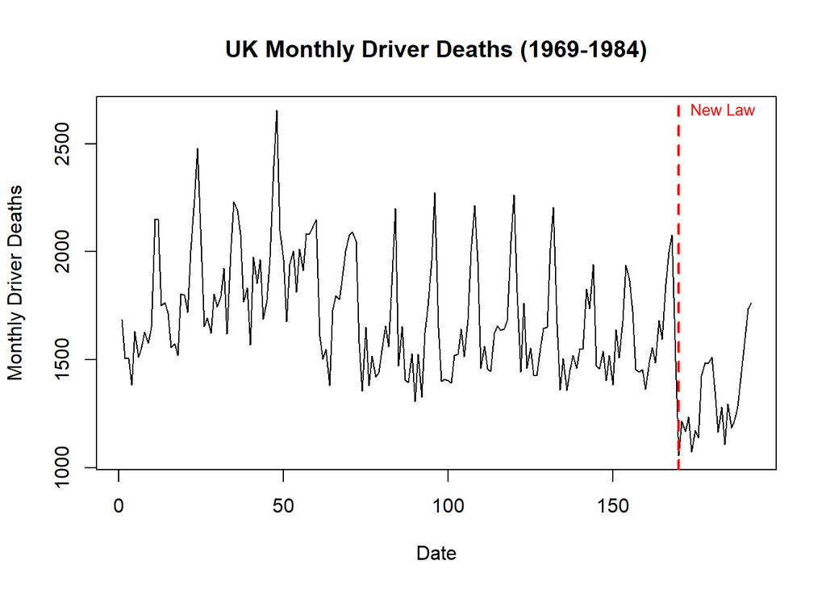

```r
# visualize the trends and point of intervention
plot(d$Time, d$Deaths, type = "l",
     xlab = "Date", ylab = "Monthly Driver Deaths",
     main = "UK Monthly Driver Deaths (1969-1984)")

abline(v = 170, col = "red", lty = 2, lwd = 2)
text(170, max(d$Deaths), "New Law", pos = 4, col = "red", cex = 0.8)
```

### Setup & Run Model

```r
# Using the variables we created, set up the ITS regression model
ITS <- lm(Deaths ~ Time + Treatment + Time_Since, data = d)

# Provide the result table using stargazer
stargazer(ITS,
          type = "html", #   !!!! Change to "html" before knitting & submitting your lab !!!
          dep.var.labels = ("Monthly Driver Deaths"),
          column.labels = ("ITS Model for Seat Belt Law"),
          covariate.labels = c("Time (Pre-Law Trend)",
                               "Treatment (Immediate Effect)",
                               "Time Since Treatment (Sustained Effect)"),
          omit.stat = "all",
          digits = 2)
```

|  | *Dependent variable:* |
| --- | --- |
|  | Monthly Driver Deaths |
|  | ITS Model for Seat Belt Law |
| Time (Pre-Law Trend) | -1.56*** |
|  | (0.39) |
| Treatment (Immediate Effect) | -457.77*** |
|  | (107.18) |
| Time Since Treatment (Sustained Effect) | 19.20** |
|  | (7.80) |
| Constant | 1,850.13*** |
|  | (38.31) |
| *Note:* | p<0.1; p<0.05; p<0.01 |

## Interpret Model Coefficients

**Constant** ($B0$): This is the estimated number of driver deaths at the start of the observation period (January 1969). $1,850.13$ suggests that, on average, there were approximately $1,850.13$ driver deaths when Time = 0 (December 1968).

**Time** ($B1$): This coefficient represents the trend in driver deaths before the intervention. A negative value indicates a decreasing trend in deaths over time prior to the law. $-1.56$ suggests that, on average, driver deaths were decreasing by approximately $1.56$ deaths per month before the seat belt law was implemented.

**Treatment** ($B2$): This coefficient captures the immediate effect of the seat belt law on driver deaths. A negative value suggests that the law led to an immediate reduction in deaths. $-457.77$ indicates that there was an immediate decrease of approximately $457.77$ driver deaths in the month following the implementation of the seat belt law. Recall, the seatbelt law came into effect the last day of January 1983, so the immediate effect is observed in February 1983 as the data is aggregated into months and not days.

**TimeSince** ($B3$): This coefficient reflects the change in trend after the intervention. Recall, the post-intervention rate is the sum of the pre-intervention trend and this coefficient. This coefficient represents the change in the pre-intervention trend after the law went into effect. The positive value of $19.20$ suggests that, after the law was enacted, the pre-law trend increased by approximately $19.20$ deaths per month from the pre-intervention rate ($-1.56$). The post-intervention trend would be $-1.56 + 19.20 = 17.64$ deaths per month.

### Possible Explanations

The positive coefficient for Time Since Treatment may seem counterintuitive given the immediate reduction in deaths. However, this could be due to several factors:

- **Behavioral Adaptation:** Over time, drivers may have adapted to the new law, leading to changes in driving behavior that could increase risk (E.g., perception of safety leads to more reckless driving).
- **Seasonal Influences:** There may be seasonal trends not fully captured in the model. Residual cycles can translate into an apparent slope change.
- **Regression to the Mean:** The immediate drop in deaths could have been followed by a natural fluctuation back towards the average trend.

## Autocorrelation

### Plot the Residuals

**Check for patterns**

Recall, in regression, our models assume that the errors are independent. We can visually inspect the residuals to see if there are any discernible patterns over time.

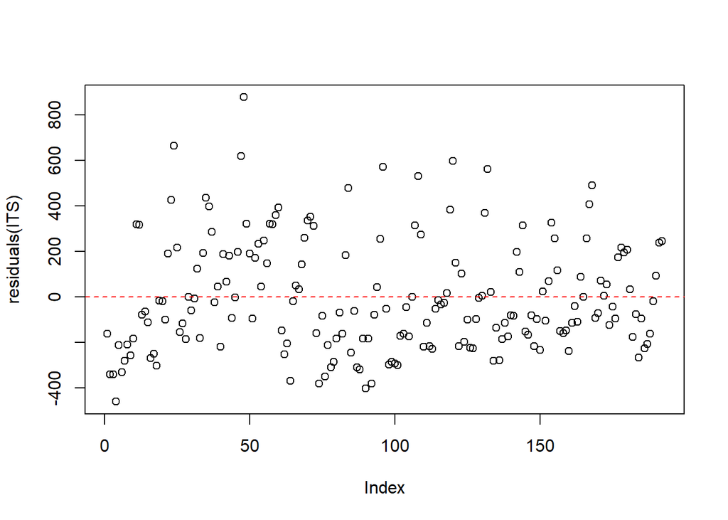

```r
# Plot the residuals over time. Check for patterns.
plot(residuals(ITS))

# Add a horizontal reference line at 0
abline(h = 0, col = "red", lty = 2)
```

As noted in the lecture, it is sometimes difficult to visually assess autocorrelation from residual plots alone. Therefore, we will use formal tests to assess autocorrelation.

### Durbin-Watson Test

We check the residuals for autocorrelation using the Durbin-Watson test.

- **Null Hypothesis ($H_0$)**: There is NO autocorrelation in the residuals (Errors are independent).
- **Alternative Hypothesis ($H_1$)**: The residuals are autocorrelated.

```r
# Use the dwtest function from the lmtest package
# We apply it to our ITS model object
dwtest(ITS)
```

```
##
##  Durbin-Watson test
##
## data:  ITS
## DW = 0.78754, p-value < 2.2e-16
## alternative hypothesis: true autocorrelation is greater than 0
```

**Interpretation:** - If the p-value is less than 0.05, we reject the null hypothesis and conclude that there is significant autocorrelation in the residuals.

- If the p-value is greater than 0.05, we fail to reject the null hypothesis, indicating that there is no significant autocorrelation in the residuals.

Given our p-value for the model is less than .05, we conclude that there is significant autocorrelation in the residuals of our ITS model. This suggests that the errors are not independent, which may affect the validity of our model estimates.

### Visualizing Autocorrelation

The Autocorrelation Function (ACF) helps us visualize the correlation of the residuals with their own past values over different time lags. vertical lines extending outside of the horizontal blue dashed lines indicate autocorrelation at that lag is statistically significant.

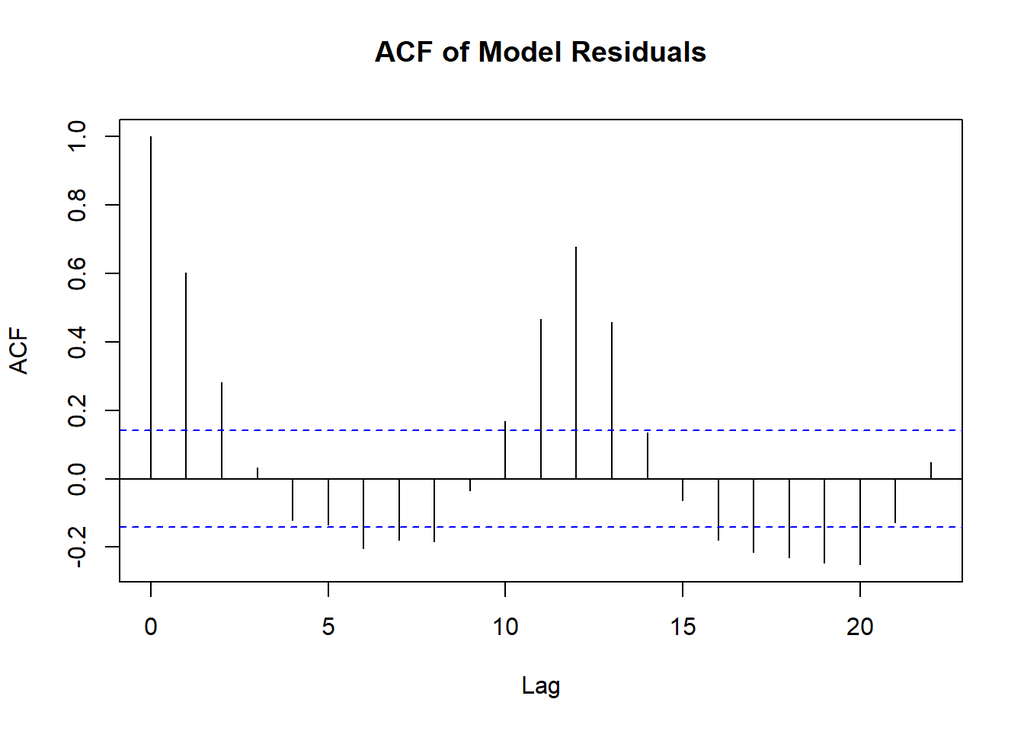

```r
acf(residuals(ITS), main = "ACF of Model Residuals")
```

Any point where the vertical lines exceed the dashed blue lines indicate significant autocorrelation at that lag. It is clear there is a cyclical nature to the autocorrelation in our residuals, confirming our earlier Durbin-Watson test results.Now, the question is, how do we resolve these? Did the seat belt law actually have an effect?

### Adjusting for Autocorrelation

**Instructor’s Note: Heteroskedasticity**

The **Newey-West method** corrects for both **heteroskedasticity** AND/OR **autocorrelation** in our data.

- If autocorrelation is present (like in this dataset), Newey-West adjusts for it.
- If no autocorrelation exists (like you might see in other datasets), but your robust standard errors still differ from your original estimates, it means the method must be correcting for heteroskedasticity instead.

**Remember this for your lab.**

In the presence of autocorrelation, our standard errors are biased, making our significance tests (p-values) untrustworthy. To refine our inference, we can utilize Robust Standard Errors using the **Newey-West method**. This method doesn’t change the coefficient estimates but adjusts the standard errors to account for both autocorrelation and heteroskedasticity (uneven variance in the data), leading to more reliable hypothesis testing. You’ll notice our significance levels change while our coefficients remain the same.

```r
# 1. Calculate the "Robust" Standard Errors (Newey-West)
# This adjusts the SEs and improves inference in the presence of autocorrelation.
robust_se <- sqrt(diag(NeweyWest(ITS)))

# 2. Display Original vs. Robust side-by-side
stargazer(ITS, ITS,
          type = "html", # Change to "html" for final knitting
          se = list(NULL, robust_se), # Col 1: Normal SEs. Col 2: Robust SEs
          column.labels = c("Original", "Robust SEs"),
          dep.var.labels = "Monthly Driver Deaths",
          covariate.labels = c("Time", "Treatment", "Time Since"),
          omit.stat = c("f", "ser"),
          digits = 2)
```

|  | *Dependent variable:* |  |
| --- | --- | --- |
|  | Monthly Driver Deaths |  |
|  | Original | Robust SEs |
|  | (1) | (2) |
| Time | -1.56*** | -1.56* |
|  | (0.39) | (0.81) |
| Treatment | -457.77*** | -457.77 |
|  | (107.18) | (286.93) |
| Time Since | 19.20** | 19.20 |
|  | (7.80) | (51.89) |
| Constant | 1,850.13*** | 1,850.13*** |
|  | (38.31) | (91.44) |
| Observations | 192 | 192 |
| R<sup>2</sup> | 0.28 | 0.28 |
| Adjusted R<sup>2</sup> | 0.27 | 0.27 |
| *Note:* | p<0.1; p<0.05; p<0.01 |  |

### Interpret the Model with RSE’s

We now see that significance disappears after adjusting for autocorrelation. This suggests that our initial findings may not be as robust as initially thought. The lack of statistical significance indicates that we cannot confidently assert that the seat belt law had a significant immediate or sustained effect on driver deaths based on this model. However, perhaps we have some confounding in our model making ascertaining the effect of the law difficult. We can include a control variable to better assess the impact of the intervention. Recall our chart using the autocorrelation function? We saw what looked like cycles in the data that may be influencing our results. Perhaps, seasonality is at play here.

## Adding a Control Variable

**Instructor’s Note:**

The following section demonstrates how to include a control variable for seasonality in the ITS model. This will not be in the lab, nor are you expected to demonstrate this in your submission. However, it is included here for completeness and to illustrate how including a control variable can unbias our estimates in the presence of autocorrelation due to seasonal patterns. The intent here is to provide students with a more comprehensive understanding of how to handle autocorrelation in a real-world ITS analysis.

### Create Control Variable

```r
# Create Month Factor Variable to Control for Seasonality
## Recall the first month in the data was January, so we assign 1 to Jan, 2 to Feb, etc. as we cycle through each row in the dataset.
d$Month <- factor(rep(1:12, length.out = nrow(d)))

# Run the ITS model WITH monthly controls
ITS_Seasonal <- lm(Deaths ~ Time + Treatment + Time_Since + Month -1, data = d)

# Display the results
stargazer(ITS_Seasonal,
          type = "html", # !!!! Change to "html" before knitting & submitting your lab !!!
          title = "ITS Model Controlling for Seasonality")
```

**ITS Model Controlling for Seasonality**

|  | *Dependent variable:* |
| --- | --- |
|  | Deaths |
| Time | -1.778*** |
|  | (0.240) |
| Treatment | -300.666*** |
|  | (66.492) |
| Time_Since | 6.871 |
|  | (4.848) |
| Month1 | 1,873.841*** |
|  | (43.181) |
| Month2 | 1,693.981*** |
|  | (42.945) |
| Month3 | 1,745.463*** |
|  | (43.005) |
| Month4 | 1,633.195*** |
|  | (43.073) |
| Month5 | 1,771.427*** |
|  | (43.152) |
| Month6 | 1,716.597*** |
|  | (43.239) |
| Month7 | 1,793.141*** |
|  | (43.336) |
| Month8 | 1,808.936*** |
|  | (43.442) |
| Month9 | 1,862.668*** |
|  | (43.558) |
| Month10 | 2,002.962*** |
|  | (43.683) |
| Month11 | 2,203.444*** |
|  | (43.816) |
| Month12 | 2,320.989*** |
|  | (43.959) |
| Observations | 192 |
| R<sup>2</sup> | 0.993 |
| Adjusted R<sup>2</sup> | 0.992 |
| Residual Std. Error | 151.988 (df = 177) |
| F Statistic | 1,580.351*** (df = 15; 177) |
| *Note:* | p<0.1; p<0.05; p<0.01 |

### Re-Check Autocorrelation

```r
# Test for autocorrelation again
dwtest(ITS_Seasonal)
```

```
##
##  Durbin-Watson test
##
## data:  ITS_Seasonal
## DW = 0.92844, p-value = 7.85e-14
## alternative hypothesis: true autocorrelation is greater than 0
```

After controlling for seasonality in our model, we continue to find significant autocorrelation in the residuals, as indicated by the Durbin-Watson test. Therefore, we will again calculate robust standard errors using the Newey-West method to adjust for this autocorrelation.

### Re-Estimate RSE’s

```r
# Check the results with Robust SEs
robust_se_seasonal <- sqrt(diag(NeweyWest(ITS_Seasonal)))

stargazer(ITS_Seasonal, ITS_Seasonal,
          type = "html", # Change to "html" for final knitting
          se = list(NULL, robust_se_seasonal),
          keep = c("Time", "Treatment", "Time_Since"), # Hide the 11 month coefficients
          title = "ITS Model Controlling for Seasonality")
```

**ITS Model Controlling for Seasonality**

|  | *Dependent variable:* |  |
| --- | --- | --- |
|  | Deaths |  |
|  | (1) | (2) |
| Time | -1.778*** | -1.778*** |
|  | (0.240) | (0.428) |
| Treatment | -300.666*** | -300.666*** |
|  | (66.492) | (43.697) |
| Time_Since | 6.871 | 6.871*** |
|  | (4.848) | (2.341) |
| Observations | 192 | 192 |
| R<sup>2</sup> | 0.993 | 0.993 |
| Adjusted R<sup>2</sup> | 0.992 | 0.992 |
| Residual Std. Error (df = 177) | 151.988 | 151.988 |
| F Statistic (df = 15; 177) | 1,580.351*** | 1,580.351*** |
| *Note:* | p<0.1; p<0.05; p<0.01 |  |

### Interpret Coefficients

**Instructor’s Note:**

Our model controlling for seasonality remains to have issues with autocorrelation, as indicated by the Durbin-Watson test. However, for the purposes of inferring treatment effect, if our robust standard errors show significance even in the presence of autocorrelation, then we can reasonably infer that the treatment effect is significant despite the autocorrelation.

- **Time** ($B1$): The coefficient for Time remains negative, indicating a decreasing trend in driver deaths before the intervention.

The value of $-1.78$ suggests that, on average, driver deaths were decreasing by approximately $1.78$ deaths per month before the seat belt law was implemented and the coefficient is statistically significant at the .01 level.

- **Treatment** ($B2$): The coefficient for Treatment is now $-300.67$, indicating an immediate decrease of approximately $-300.67$ driver deaths in the month following the implementation of the seat belt law. This effect is smaller than in the previous model but remains statistically significant at the .01 level.
- **TimeSince** ($B3$): The coefficient for Time Since Treatment is now $6.87$, suggesting that after the law was enacted, the trend in driver deaths increased by approximately $6.87$ deaths per month. This indicates a less pronounced increase in deaths post-intervention compared to the previous model, and it is statistically significant at the .01 level. Refer back to the Possible Explanations section for interpretations of this sustained effect. *Autocorrelation can effect standard errors in either direction. The lack of significance prior to running robust standard errors reveals autocorrelation was inflating our standard errors, making it more difficult to detect significance.*

## Counterfactual

To visualize the counterfactual scenario we can predict the driver deaths using the model coefficients, setting the Treatment and Time Since variables to zero for all time points. The following section will demonstrate how to calculate counterfactuals at specific time points post-intervention.

### Formula

The counterfactual formula can be expressed as:

$Y_{t} = B0 + B1 \cdot Time_{t}$

- $Y_{t}$ is the predicted number of deaths at time $t$
- $B0$ is the intercept
- $B1$ is the coefficient for Time.

**Instructor’s Note:**

The counterfactual calculations below include a **Month** variable because this tutorial model controls for seasonality.

**Your lab will use a simpler model without this control.** When you write this code for your lab, simply **omit the Month variable** from your data.frame() and predict() functions. The logic and steps remain exactly the same, but your code will be shorter.

### Calculate Counterfactuals

#### What is the number of deaths 12 months after treatment (February 1984 | Time = 182)?

Let’s first see what actually occurred, then compare it to the counterfactual.

```r
# Subset the value of Deaths at Time = 182 (Feb 1984)
Deaths_182 <- d$Deaths[182]

print(paste("Actual Deaths Post-Treatment (Feb 1984):", Deaths_182))
```

```
## [1] "Actual Deaths Post-Treatment (Feb 1984): 1165"
```

#### What is the counterfactual 12 months after treatment (Feb 1984 | Time = 182)?

We will use the `predict()` function to estimate the value based on our model’s coefficients.

- **Time:** 182 (Feb 1984)
- **Treatment:** 0 (The law never went into effect)
- **Time_Since:** 0 (The law never went into effect)
- **Month:** 2 (February)

```r
# Create a new data frame for 12 months post-intervention (Counterfactual)
d_cf_182 <- data.frame(Time = 182, Treatment = 0, Time_Since = 0, Month = factor(2))

# Predict
val_cf_182 <- predict(ITS_Seasonal, d_cf_182)

print(paste("Counterfactual Deaths (Feb 1984):", round(val_cf_182, 0)))
```

```
## [1] "Counterfactual Deaths (Feb 1984): 1370"
```

#### Calculate and explain the difference between the actual and counterfactual at 12 months post-intervention?

```r
# Calculate the difference between actual and counterfactual deaths
difference_182 <- val_cf_182 - Deaths_182

print(paste("Estimated Reduction in Deaths (Lives Saved):", round(difference_182, 0)))
```

```
## [1] "Estimated Reduction in Deaths (Lives Saved): 205"
```

#### What is the number of deaths 22 months after treatment (Dec 1984 | Time = 192)?

```r
# Subset the value of Deaths at Time = 192 (Dec 1984)
Deaths_192 <- d$Deaths[192]

print(paste("Actual Deaths Post-Treatment (Dec 1984):", Deaths_192))
```

```
## [1] "Actual Deaths Post-Treatment (Dec 1984): 1763"
```

#### What is the counterfactual 22 months after treatment (December 1984 | Time = 192)?

We will use the `predict()` function to estimate the value based on our model’s coefficients.

- **Time:** 192 (Dec 1984)
- **Treatment:** 0 (The law never went into effect)
- **Time_Since:** 0 (The law never went into effect)
- **Month:** 12 (December)

```r
# Create a new data frame for 22 months post-intervention (Counterfactual)
d_cf_192 <- data.frame(Time = 192, Treatment = 0, Time_Since = 0, Month = factor(12))

# Predict
val_cf_192 <- predict(ITS_Seasonal, d_cf_192)

print(paste("Counterfactual Deaths (Dec 1984):", round(val_cf_192, 0)))
```

```
## [1] "Counterfactual Deaths (Dec 1984): 1980"
```

#### What is the difference between the actual and counterfactual at 22 months post-intervention?

```r
# Calculate the difference between actual and counterfactual deaths
difference_192 <- val_cf_192 - Deaths_192

print(paste("Estimated Reduction in Deaths (Lives Saved):", round(difference_192, 0)))
```

```
## [1] "Estimated Reduction in Deaths (Lives Saved): 217"
```

#### What, if any, are the technical differences between the two counterfactual estimates?

**Instructor’s Note:**

The following answer is ignoring the fact our codethrough utilizes seasonality as a control variable and answers as if that variable was not part of our model. This more accurately replicates the expected response to the lab question.

The technical difference between the two counterfactual estimates lies in the Time variable used in the predictions. Each counterfactual represents a different point in time, but both assuming the treatment had never occurred.

## The Final Verdict

### Summary Table: Model Progression

```r
# Create comparison table of key coefficients across models
stargazer(ITS, ITS, ITS_Seasonal, ITS_Seasonal,
          type = "html", # Change to "html" for final knitting
          se = list(NULL, robust_se, NULL, robust_se_seasonal),
          column.labels = c("Naive Model", "Naive (Robust SE)",
                            "Seasonality", "Seasonality (Robust SE)"),
          dep.var.labels = "Monthly Driver Deaths",
          omit.stat = "all",
          digits = 2)
```

|  | *Dependent variable:* |  |  |  |
| --- | --- | --- | --- | --- |
|  | Monthly Driver Deaths |  |  |  |
|  | Naive Model | Naive (Robust SE) | Seasonality | Seasonality (Robust SE) |
|  | (1) | (2) | (3) | (4) |
| Time | -1.56*** | -1.56* | -1.78*** | -1.78*** |
|  | (0.39) | (0.81) | (0.24) | (0.43) |
| Treatment | -457.77*** | -457.77 | -300.67*** | -300.67*** |
|  | (107.18) | (286.93) | (66.49) | (43.70) |
| Time_Since | 19.20** | 19.20 | 6.87 | 6.87*** |
|  | (7.80) | (51.89) | (4.85) | (2.34) |
| Month1 |  |  | 1,873.84*** | 1,873.84*** |
|  |  |  | (43.18) | (66.52) |
| Month2 |  |  | 1,693.98*** | 1,693.98*** |
|  |  |  | (42.95) | (60.15) |
| Month3 |  |  | 1,745.46*** | 1,745.46*** |
|  |  |  | (43.00) | (53.81) |
| Month4 |  |  | 1,633.20*** | 1,633.20*** |
|  |  |  | (43.07) | (61.52) |
| Month5 |  |  | 1,771.43*** | 1,771.43*** |
|  |  |  | (43.15) | (63.72) |
| Month6 |  |  | 1,716.60*** | 1,716.60*** |
|  |  |  | (43.24) | (63.69) |
| Month7 |  |  | 1,793.14*** | 1,793.14*** |
|  |  |  | (43.34) | (64.74) |
| Month8 |  |  | 1,808.94*** | 1,808.94*** |
|  |  |  | (43.44) | (57.80) |
| Month9 |  |  | 1,862.67*** | 1,862.67*** |
|  |  |  | (43.56) | (60.49) |
| Month10 |  |  | 2,002.96*** | 2,002.96*** |
|  |  |  | (43.68) | (64.39) |
| Month11 |  |  | 2,203.44*** | 2,203.44*** |
|  |  |  | (43.82) | (54.59) |
| Month12 |  |  | 2,320.99*** | 2,320.99*** |
|  |  |  | (43.96) | (68.02) |
| Constant | 1,850.13*** | 1,850.13*** |  |  |
|  | (38.31) | (91.44) |  |  |
| *Note:* | p<0.1; p<0.05; p<0.01 |  |  |  |

### Visualize Treatment Effect

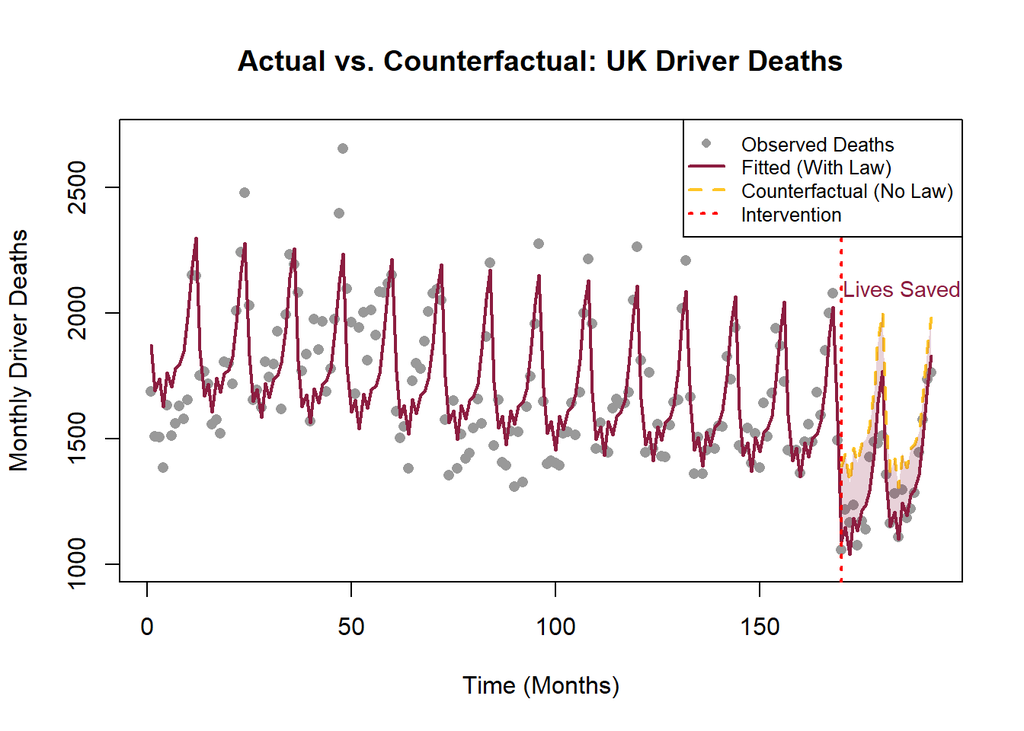

```r
# Generate predictions for actual scenario (with treatment)
d$predicted_actual <- predict(ITS_Seasonal, d)

# Generate predictions for counterfactual (no treatment)
d_counterfactual <- d
d_counterfactual$Treatment <- 0
d_counterfactual$Time_Since <- 0
d$predicted_counterfactual <- predict(ITS_Seasonal, d_counterfactual)

# Create the plot
plot(d$Time, d$Deaths, type = "p", pch = 16, col = "gray60",
     xlab = "Time (Months)", ylab = "Monthly Driver Deaths",
     main = "Actual vs. Counterfactual: UK Driver Deaths",
     ylim = c(1000, 2700))

# Add fitted line for actual scenario
lines(d$Time, d$predicted_actual, col = "#8C1D40", lwd = 2)

# Add counterfactual projection (post-intervention only)
lines(d$Time[d$Time >= 170], d$predicted_counterfactual[d$Time >= 170],
      col = "#FFC627", lwd = 2, lty = 2)

# Add vertical line at intervention
abline(v = 170, col = "red", lty = 3, lwd = 2)

# Add legend
legend("topright",
       legend = c("Observed Deaths", "Fitted (With Law)",
                  "Counterfactual (No Law)", "Intervention"),
       col = c("gray60", "#8C1D40", "#FFC627", "red"),
       lty = c(NA, 1, 2, 3),
       pch = c(16, NA, NA, NA),
       lwd = c(NA, 2, 2, 2),
       cex = 0.8)

# Shade the "lives saved" area
polygon(x = c(170:192, 192:170),
        y = c(d$predicted_counterfactual[170:192],
              rev(d$predicted_actual[170:192])),
        col = rgb(0.55, 0.11, 0.25, alpha = 0.2), # Transparent maroon
        border = NA)

text(185, 2100, "Lives Saved", col = "#8C1D40", cex = 0.9, font = 1.5)
```

### Effect Size: Lives Saved

```r
# Calculate total lives saved over the post-intervention period
post_intervention_period <- d[d$Time >= 170, ]

# Sum of differences between counterfactual and actual
total_lives_saved <- sum(post_intervention_period$predicted_counterfactual -
                         post_intervention_period$Deaths)

# Average monthly reduction
avg_monthly_reduction <- mean(post_intervention_period$predicted_counterfactual -
                              post_intervention_period$Deaths)

cat("Total Lives Saved (Feb 1983 - Dec 1984):", round(total_lives_saved, 0), "\n",
    "Average Monthly Reduction:", round(avg_monthly_reduction, 0), "deaths per month\n")
```

```
## Total Lives Saved (Feb 1983 - Dec 1984): 5177
##  Average Monthly Reduction: 225 deaths per month
```

### Did the law work?

We began this analysis by fitting a naive Interrupted Time Series model, which initially suggested a massive and statistically significant reduction in driver deaths. However, as evaluators, we must verify that our model meets the assumptions of linear regression.

**1. The Diagnostic:** Our diagnostics—specifically the Durbin-Watson test and ACF plots—revealed significant autocorrelation. This indicated that our data contained internal patterns (likely seasonality) that were inflating our “significance” levels, rendering our initial standard errors untrustworthy.

**2. The Correction:** To address this bias, we took two approaches:

- **Robust Standard Errors (Newey-West):** This adjusts standard errors for autocorrelation without changing coefficients
- **Seasonality Controls:** We added monthly fixed effects to capture cyclical patterns in the data

**3. The Conclusion:** After these rigorous adjustments, where did we land?

- **Behavioral adaptation:** Drivers feeling safer and taking more risks
- **Regression to the mean:** Natural fluctuation back toward historical averages
- **Enforcement changes:** Initial strict enforcement may have waned over time

**Bottom Line:** Yes, the evidence suggests the law worked in the short term, preventing approximately **5177 deaths** over the 23-month post-intervention period studied. However, the long-term trend highlights the complexity of public policy interventions, where initial success does not always guarantee a permanent shift in trend without continued enforcement, public awareness campaigns, or complementary policies.

## Utilizing Control Group

**Since the `UKDriverDeaths` dataset does not have a real-world control group included, we will generate a synthetic one to demonstrate building a model with a control group using ITS.**

**Instructor’s Note:**

You are not required to generate a control group for your lab submission. The following code is provided to demonstrate how to run an Interrupted Time Series analysis with a comparison group. The use of simulated data for our control is for educational purposes only.

### Interrupted Time Series Model w/ Control Group:

$$Y = b_0 + b_1 T + b_2 D + b_3 P + b_4 G
+ b_5 GT + b_6 GD + b_7 GP$$

- **Y**: Monthly Driver Deaths
- **T**: Time (continuous)
- **D**: Treatment (0 = pre-intervention, 1 = post-intervention)
- **P**: Time Since Intervention (0 before and on intervention, counts up from 1 after)
- **G**: Group (0 = Control, 1 = Treatment)

### Create Simulated Control Group Data

We generate faux data to act as our control group.

```r
# Generate Synthetic Control Data
set.seed(123)

# Create a control group with similar baseline but NO drop in 1983
control_deaths <- d$Deaths + rnorm(length(d$Deaths), mean = 200, sd = 50)

# Ensure no intervention effect (remove the drop at t=170)
control_deaths[170:192] <- control_deaths[170:192] + 400

# Structure the Data
# Control Group Dataframe
d_control <- data.frame(
  Deaths = control_deaths,
  Time = d$Time,
  Treatment = d$Treatment,
  Time_Since = d$Time_Since,
  Group = 0 # 0 = Control Group
)

# Treatment Group Dataframe (The original UK data)
d_treatment <- data.frame(
  Deaths = d$Deaths,
  Time = d$Time,
  Treatment = d$Treatment,
  Time_Since = d$Time_Since,
  Group = 1 # 1 = Treatment Group
)

# Combine them
d_grouped <- rbind(d_treatment, d_control)
d_grouped$Group <- as.factor(d_grouped$Group)
```

### Model and Interpret ITS with Control Group

```r
# Model and run ITS with reference group
# We interact Group with every time variable
Group_ITS <- lm(Deaths ~ Time + Treatment + Time_Since + Group
            + Time*Group + Treatment*Group + Time_Since*Group,
            data = d_grouped)

# Note, for interaction terms you can also use a colon, the result is the same.
# Group:Time + Group:Treatment + Group:Time_Since

stargazer(Group_ITS,
          type = "html", # Change to "html" for final knitting
          dep.var.labels = ("Monthly Driver Deaths"),
          column.labels = ("CITS Results"),
          covariate.labels = c(
                               "Group (Difference at Baseline)",
                               "Time * Group (Diff in Pre-Trend)",
                               "Treatment * Group (Diff in Immediate Effect)",
                               "TimeSince * Group (Diff in Sustained Effect)"),
          # We only focus on the group level coefficients
          keep = c("Group", "Time*Group", "Treatment*Group", "Time_Since*Group"),
          omit.stat = "all",
          digits = 2)
```

|  | *Dependent variable:* |
| --- | --- |
|  | Monthly Driver Deaths |
|  | CITS Results |
| Group (Difference at Baseline) | -203.34*** |
|  | (54.26) |
| Time * Group (Diff in Pre-Trend) | 0.04 |
|  | (0.55) |
| Treatment * Group (Diff in Immediate Effect) | -407.62*** |
|  | (151.80) |
| TimeSince * Group (Diff in Sustained Effect) | 0.22 |
|  | (11.05) |
| *Note:* | p<0.1; p<0.05; p<0.01 |

**Group (-203.34):** The baseline difference between the groups. At Time = 0, the Treatment group had approximately 203 fewer deaths than the Control group and the coefficient was statistically significant.

**Time* Group (0.04):** The difference in the pre-intervention trend. The Treatment group’s trend was virtually identical to the Control group’s trend before the intervention (*not statistically significant*).

**Treatment * Group (-407.62):** The “Difference-in-Differences” (immediate effect). Relative to the Control group, the Treatment group saw an immediate drop of approximately 408 deaths when the law was implemented and the coefficient was statistically significant.

**TimeSince * Group (0.22):** The difference in the sustained effect. The change in the slope after the intervention for the Treatment group *was not statistically different* from the Control group. The treatment was not impactful over-time.